# chapter4.rmd

Perttu Kajatkari

11/18/2020

```r
#load libraries
library(dplyr); library(ggplot2); library(corrplot)
library(MASS); library(tidyr)
```

## Reading in and exploring the data

In this weeks exercise we analysed “Boston” dataset from MASS-library. The dataset contains housing values in Boston suburbs in terms of median value of owner-occupied homes, including various other variables, such as crime rate, pollution, etc..

```r
#Let's take a look at the data
data("Boston")
str(Boston)
```

```
## 'data.frame':    506 obs. of  14 variables:
##  $ crim   : num  0.00632 0.02731 0.02729 0.03237 0.06905 ...
##  $ zn     : num  18 0 0 0 0 0 12.5 12.5 12.5 12.5 ...
##  $ indus  : num  2.31 7.07 7.07 2.18 2.18 2.18 7.87 7.87 7.87 7.87 ...
##  $ chas   : int  0 0 0 0 0 0 0 0 0 0 ...
##  $ nox    : num  0.538 0.469 0.469 0.458 0.458 0.458 0.524 0.524 0.524 0.524 ...
##  $ rm     : num  6.58 6.42 7.18 7 7.15 ...
##  $ age    : num  65.2 78.9 61.1 45.8 54.2 58.7 66.6 96.1 100 85.9 ...
##  $ dis    : num  4.09 4.97 4.97 6.06 6.06 ...
##  $ rad    : int  1 2 2 3 3 3 5 5 5 5 ...
##  $ tax    : num  296 242 242 222 222 222 311 311 311 311 ...
##  $ ptratio: num  15.3 17.8 17.8 18.7 18.7 18.7 15.2 15.2 15.2 15.2 ...
##  $ black  : num  397 397 393 395 397 ...
##  $ lstat  : num  4.98 9.14 4.03 2.94 5.33 ...
##  $ medv   : num  24 21.6 34.7 33.4 36.2 28.7 22.9 27.1 16.5 18.9 ...
```

```r
summary(Boston)
```

```
##       crim                zn             indus            chas
##  Min.   : 0.00632   Min.   :  0.00   Min.   : 0.46   Min.   :0.00000
##  1st Qu.: 0.08205   1st Qu.:  0.00   1st Qu.: 5.19   1st Qu.:0.00000
##  Median : 0.25651   Median :  0.00   Median : 9.69   Median :0.00000
##  Mean   : 3.61352   Mean   : 11.36   Mean   :11.14   Mean   :0.06917
##  3rd Qu.: 3.67708   3rd Qu.: 12.50   3rd Qu.:18.10   3rd Qu.:0.00000
##  Max.   :88.97620   Max.   :100.00   Max.   :27.74   Max.   :1.00000
##       nox               rm             age              dis
##  Min.   :0.3850   Min.   :3.561   Min.   :  2.90   Min.   : 1.130
##  1st Qu.:0.4490   1st Qu.:5.886   1st Qu.: 45.02   1st Qu.: 2.100
##  Median :0.5380   Median :6.208   Median : 77.50   Median : 3.207
##  Mean   :0.5547   Mean   :6.285   Mean   : 68.57   Mean   : 3.795
##  3rd Qu.:0.6240   3rd Qu.:6.623   3rd Qu.: 94.08   3rd Qu.: 5.188
##  Max.   :0.8710   Max.   :8.780   Max.   :100.00   Max.   :12.127
##       rad              tax           ptratio          black
##  Min.   : 1.000   Min.   :187.0   Min.   :12.60   Min.   :  0.32
##  1st Qu.: 4.000   1st Qu.:279.0   1st Qu.:17.40   1st Qu.:375.38
##  Median : 5.000   Median :330.0   Median :19.05   Median :391.44
##  Mean   : 9.549   Mean   :408.2   Mean   :18.46   Mean   :356.67
##  3rd Qu.:24.000   3rd Qu.:666.0   3rd Qu.:20.20   3rd Qu.:396.23
##  Max.   :24.000   Max.   :711.0   Max.   :22.00   Max.   :396.90
##      lstat            medv
##  Min.   : 1.73   Min.   : 5.00
##  1st Qu.: 6.95   1st Qu.:17.02
##  Median :11.36   Median :21.20
##  Mean   :12.65   Mean   :22.53
##  3rd Qu.:16.95   3rd Qu.:25.00
##  Max.   :37.97   Max.   :50.00
```

```r
dim(Boston)
```

```
## [1] 506  14
```

Everything seems to be in order. Next I checked the data correlations and distributions.

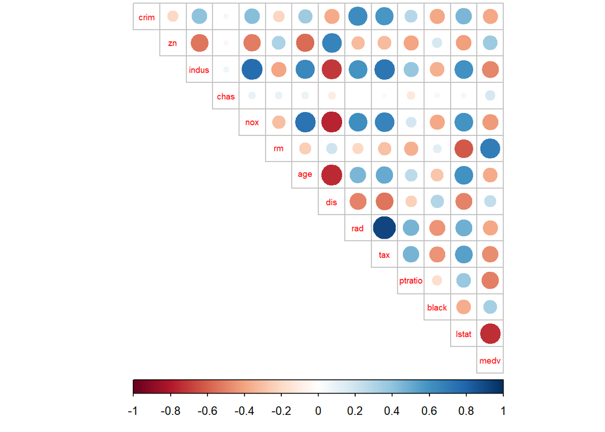

```r
#Let's have a looksie. Since there are quite a few variables, plot each
#plot type separately, instead of using, e.g., pairs.

#Correlations
cor_matrix<-cor(Boston)
corrplot(cor_matrix, method="circle",type='upper',cl.pos = "b", tl.pos = "d" ,tl.cex = 0.6)
```

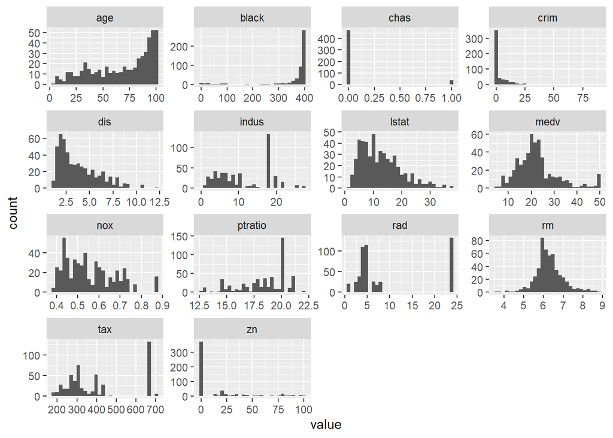

```r
#Histograms
Boston %>%  gather() %>%
  ggplot(aes(value)) +
    facet_wrap(~ key, scales = "free") +
    geom_histogram()
```

There appear to be clear correlations between some of the variables. This is quite expected, since, for instance, industrial areas (indus) are more likely to be more polluted (nox). Also it is not that surprising, that more expensive neighbourhoods have less crime (medv vs crim), and sub urbs with residents of lower socio-economic status (lstat) have higher rates of crime.

Looking at the histograms, it is quite clear that only some of the variables appear to be normally distributed, whereas most are not. This is actually quite worrying, since the fundamental assumption of linear discriminant analysis is that the exploratory variables are normally distributed. Nevertheless, we boldly proceed.

## Scaling and preparing the data

Next, I scaled the data in order to prepare it for the clustering algorithms.

```r
#scale the dataset
boston_scaled <- as.data.frame(scale(Boston))
summary(boston_scaled)
```

```
##       crim                 zn               indus              chas
##  Min.   :-0.419367   Min.   :-0.48724   Min.   :-1.5563   Min.   :-0.2723
##  1st Qu.:-0.410563   1st Qu.:-0.48724   1st Qu.:-0.8668   1st Qu.:-0.2723
##  Median :-0.390280   Median :-0.48724   Median :-0.2109   Median :-0.2723
##  Mean   : 0.000000   Mean   : 0.00000   Mean   : 0.0000   Mean   : 0.0000
##  3rd Qu.: 0.007389   3rd Qu.: 0.04872   3rd Qu.: 1.0150   3rd Qu.:-0.2723
##  Max.   : 9.924110   Max.   : 3.80047   Max.   : 2.4202   Max.   : 3.6648
##       nox                rm               age               dis
##  Min.   :-1.4644   Min.   :-3.8764   Min.   :-2.3331   Min.   :-1.2658
##  1st Qu.:-0.9121   1st Qu.:-0.5681   1st Qu.:-0.8366   1st Qu.:-0.8049
##  Median :-0.1441   Median :-0.1084   Median : 0.3171   Median :-0.2790
##  Mean   : 0.0000   Mean   : 0.0000   Mean   : 0.0000   Mean   : 0.0000
##  3rd Qu.: 0.5981   3rd Qu.: 0.4823   3rd Qu.: 0.9059   3rd Qu.: 0.6617
##  Max.   : 2.7296   Max.   : 3.5515   Max.   : 1.1164   Max.   : 3.9566
##       rad               tax             ptratio            black
##  Min.   :-0.9819   Min.   :-1.3127   Min.   :-2.7047   Min.   :-3.9033
##  1st Qu.:-0.6373   1st Qu.:-0.7668   1st Qu.:-0.4876   1st Qu.: 0.2049
##  Median :-0.5225   Median :-0.4642   Median : 0.2746   Median : 0.3808
##  Mean   : 0.0000   Mean   : 0.0000   Mean   : 0.0000   Mean   : 0.0000
##  3rd Qu.: 1.6596   3rd Qu.: 1.5294   3rd Qu.: 0.8058   3rd Qu.: 0.4332
##  Max.   : 1.6596   Max.   : 1.7964   Max.   : 1.6372   Max.   : 0.4406
##      lstat              medv
##  Min.   :-1.5296   Min.   :-1.9063
##  1st Qu.:-0.7986   1st Qu.:-0.5989
##  Median :-0.1811   Median :-0.1449
##  Mean   : 0.0000   Mean   : 0.0000
##  3rd Qu.: 0.6024   3rd Qu.: 0.2683
##  Max.   : 3.5453   Max.   : 2.9865
```

```r
#Mean vanished, what about the sdev?
apply(boston_scaled,2,sd)
```

```
##    crim      zn   indus    chas     nox      rm     age     dis     rad     tax
##       1       1       1       1       1       1       1       1       1       1
## ptratio   black   lstat    medv
##       1       1       1       1
```

The scale() function does column-wise operations to the data. First it removes the mean from each column and then divides the residuals with their standard deviation.

Next I created a new categorical variable from the crime rate by creating quantiles according to how high or low the crime rate was. For model validation, the data was also split into test and training sets.

```r
bins <- quantile(boston_scaled$crim)
crime <- cut(boston_scaled$crim, breaks = bins, include.lowest = TRUE, label=c("low", "med_low", "med_high", "high"))
# remove original crim from the dataset
boston_scaled <- dplyr::select(boston_scaled, -crim)
# add the new categorical value to scaled data
boston_scaled <- data.frame(boston_scaled, crime)


# number of rows in the Boston dataset
n <- nrow(boston_scaled)
# choose randomly 80% of the rows
ind <- sample(n,  size = n * 0.8)
# create train set
train <- boston_scaled[ind,]
# create test set
test <- boston_scaled[-ind,]
```

## Linear discriminant analysis

Next, I applied linear discriminant analysis (LDA) to the training data. LDA is a statistical method that tries to separate two or more classes of objects by finding a linear combination of features that can be used as an optimal separator.

```r
# linear discriminant analysis
#crime is the target variable, . indicates that all the other are explanatory
#variables
lda.fit <- lda(crime ~ . , data = train)

# print the lda.fit object
lda.fit
```

```
## Call:
## lda(crime ~ ., data = train)
##
## Prior probabilities of groups:
##       low   med_low  med_high      high
## 0.2549505 0.2475248 0.2500000 0.2475248
##
## Group means:
##                   zn      indus        chas        nox          rm        age
## low       1.01096189 -0.8814093 -0.08120770 -0.8679886  0.45377719 -0.8716540
## med_low  -0.09234176 -0.2596920 -0.07547406 -0.5289635 -0.18521379 -0.3008968
## med_high -0.37516530  0.1241101  0.19544522  0.3189433  0.07021734  0.3873449
## high     -0.48724019  1.0171519 -0.03610305  1.0728118 -0.49598048  0.8056844
##                 dis        rad        tax     ptratio       black        lstat
## low       0.8583249 -0.6941969 -0.7410673 -0.46647942  0.38353105 -0.776536687
## med_low   0.2951305 -0.5500476 -0.4269514 -0.04689892  0.34581976 -0.089393326
## med_high -0.3257372 -0.3848958 -0.2969028 -0.21635874  0.09259875  0.006350961
## high     -0.8420241  1.6377820  1.5138081  0.78037363 -0.77594104  0.956627631
##                 medv
## low       0.53849891
## med_low  -0.05173436
## med_high  0.14251856
## high     -0.72553341
##
## Coefficients of linear discriminants:
##                 LD1          LD2         LD3
## zn       0.12517306  0.830579809 -0.78110449
## indus   -0.01044092 -0.149180420  0.13618389
## chas    -0.06303853 -0.052809547  0.03496999
## nox      0.43479720 -0.644563710 -1.44082575
## rm      -0.10840096 -0.074291149 -0.14985319
## age      0.32078960 -0.317566443 -0.29536676
## dis     -0.01139260 -0.327235518 -0.10863310
## rad      3.03478065  1.012838512 -0.26565468
## tax     -0.06770159 -0.175149861  0.87247599
## ptratio  0.12174454  0.008890209 -0.26474044
## black   -0.15561023  0.002542113  0.13349243
## lstat    0.21042829 -0.291549961  0.38691727
## medv     0.18766214 -0.439000130 -0.26301456
##
## Proportion of trace:
##    LD1    LD2    LD3
## 0.9487 0.0374 0.0138
```

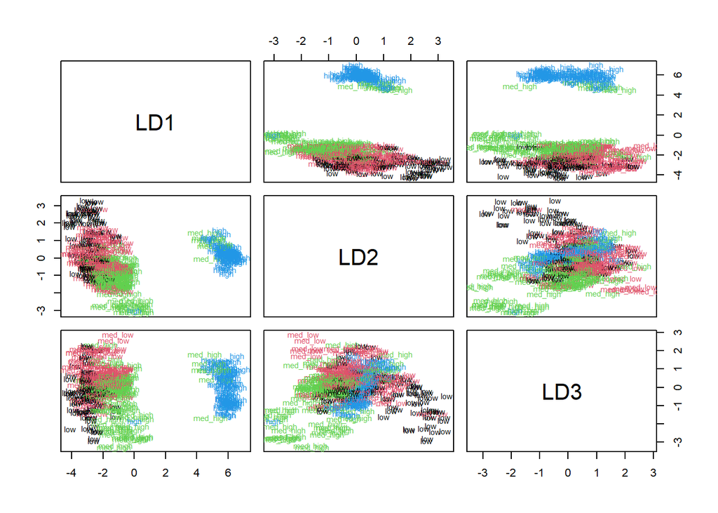

```r
classes <- as.numeric(train$crime)
plot(lda.fit,dimen=3,col = classes,pch = classes)
```

Some clusters clearly emerge. As a next step, I tested the predictive power of the model, using a subset of the original dataset, with the real category included.

```r
# save the correct classes from test data
correct_classes <- test$crime
# remove the crime variable from test data
test <- dplyr::select(test, -crime)
#Make a prediction
lda.pred <- predict(lda.fit, newdata = test)
#and tabulate the results
table(correct = correct_classes, predicted = lda.pred$class)
```

```
##           predicted
## correct    low med_low med_high high
##   low       15       9        0    0
##   med_low    6      14        6    0
##   med_high   0       4       21    0
##   high       0       0        0   27
```

## K-means clustering

To further analyze the data, I applied K-means clustering to the dataset.

```r
#Since the Boston dataset is untouched, it can be used as-is.
#Rewrite the boston_scaled variable
boston_scaled <- as.data.frame(scale(Boston))

#Check out the distance measures
dist_boston <- dist(Boston)
summary(dist_boston)
```

```
##    Min. 1st Qu.  Median    Mean 3rd Qu.    Max.
##   1.119  85.624 170.539 226.315 371.950 626.047
```

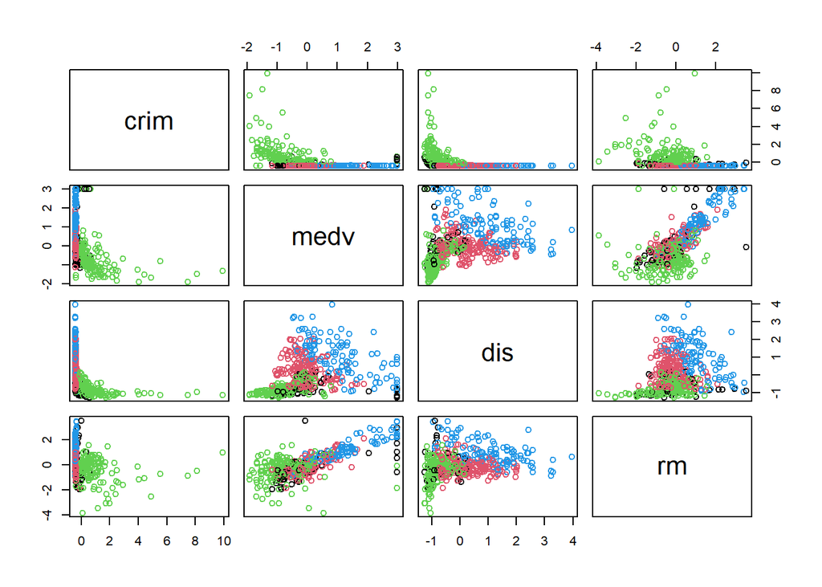

```r
km <-kmeans(boston_scaled, centers = 4)
pairs(boston_scaled[c("crim","medv","dis","rm")], col=km$cluster)
```

An important part of clustering is to actually determine, what is the optimal number of clusters. It can be estimated from the the total cluster sum of squares. The optimum number can be found where the sum changes radically.

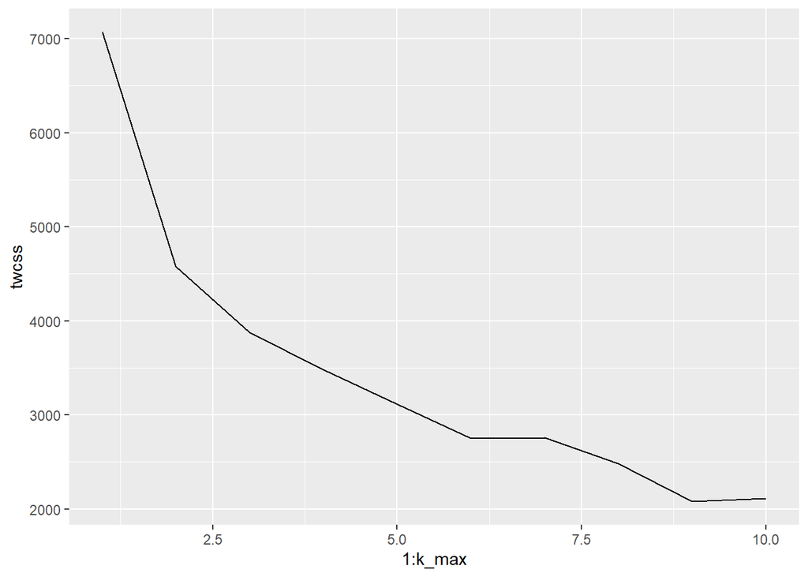

```r
k_max <- 10
# calculate the total within sum of squares
twcss <- sapply(1:k_max, function(k){kmeans(boston_scaled, k)$tot.withinss})

# visualize the results
qplot(x = 1:k_max, y = twcss, geom = 'line')
```

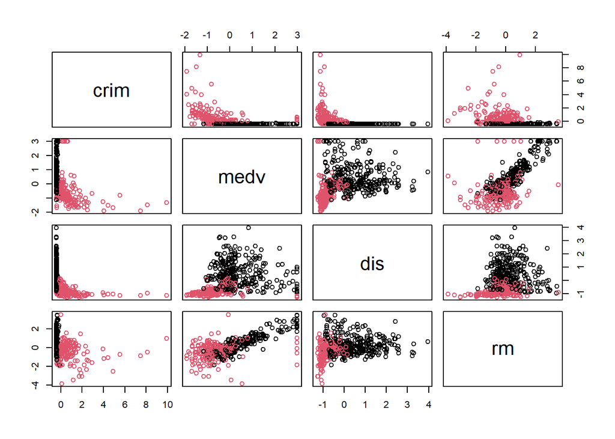

```r
km <-kmeans(boston_scaled, centers = 2)
pairs(boston_scaled[c("crim","medv","dis","rm")], col=km$cluster)
```

In this case, the optimum number of clusters appeared to be 2. Two clusters clearly separate the dataset to areas, where the crime is virtually non-existent, and to areas, where there is crime.

```r
#Since the Boston dataset is untouched, it can be used as-is.
#Rewrite the boston_scaled variable
boston_scaled <- as.data.frame(scale(Boston))

#Use four clusters this time
km <-kmeans(boston_scaled, centers = 4)
clusters = km$cluster
lda.fit <- lda(crim ~ . , data = boston_scaled)
```

[figure not shown]

```
## integer(0)
```

```r
lda.arrows <- function(x, myscale = 1, arrow_heads = 0.1, color = "red", tex = 0.75, choices = c(1,2)){
  heads <- coef(x)

  arrows(x0 = 0, y0 = 0,
         x1 = myscale * heads[,choices[1]],
         y1 = myscale * heads[,choices[2]], col=color, length = arrow_heads)
  text(myscale * heads[,choices], labels = row.names(heads),
       cex = tex, col=color, pos=3)
}


#plot(lda.fit,dimen=2,col = clusters,pch = clusters)
plot(lda.fit,dimen=2,col = clusters,pch = clusters)+lda.arrows(lda.fit,myscale=2.0)
```

It seems the sub-urban areas are divided quite strongly into industrial areas (indu) and areas predominately populated by black people (black=(1000(Bk - 0.63)^2 where Bk is the proportion of blacks by town. ), as these seem to be the strongest linear separators.

## Data wrangling for the next week.

This is done by a script create_human.R